# Royal Society Corpus: How Metadata Enables Different Research Questions

## 4. Combining Metadata

When multiple perspectives are brought together one can ask more complex questions. For example:

**Research Questions**:

- How do multiple metadata dimensions interact to shape scientific discourse?
- What happens when we layer temporal, topical, and social factors together?
- How can we trace the evolution of specific scientific communities or disciplines?
- What complex patterns emerge only when combining different types of context?

**Methodological Strength(s):** This represents the full potential of metadata-driven analysis—the ability to ask complex, multi-faceted questions that would be impossible with any single dimension of context.

Example Applications:

- Tracking how specific scientific communities evolved their language over time
- Comparing how different fields adopted new terminology during the same period
- Analysing how collaboration patterns vary across disciplines and historical periods
- Investigating how major scientific discoveries propagated through different networks

```r
# Example: How did physics language change from 1800s to 1900s?
physics_topics <- c("Atomic Physics", "Thermodynamics", "Fluid Dynamics", "Electricity")

# Create combined subsets
dfm_phys_1800s <- subset_corpus(rsc_dfm,
                              topics = physics_topics,
                              start_year = 1800, end_year = 1899)

dfm_phys_1900s <- subset_corpus(rsc_dfm,
                              topics = physics_topics,
                              start_year = 1900, end_year = 1920)

cat(physics_topics, "in 1800s:\n")
```

```
## Atomic Physics Thermodynamics Fluid Dynamics Electricity in 1800s:
```

```r
cat("Documents:", ndoc(dfm_phys_1800s), "\n")
```

```
## Documents: 1786
```

```r
cat("\n", physics_topics, "in 1900s:\n")
```

```
##
##  Atomic Physics Thermodynamics Fluid Dynamics Electricity in 1900s:
```

```r
cat("Documents:", ndoc(dfm_phys_1900s), "\n\n")
```

```
## Documents: 1030
```

```r
cat("Top terms in", physics_topics, "1800s:\n")
```

```
## Top terms in Atomic Physics Thermodynamics Fluid Dynamics Electricity 1800s:
```

```r
topfeatures(dfm_phys_1800s, 10) %>% print()
```

```
## temperature experiments        tube         air     current       lines
##       15660       14551       12557       12493       12180       12021
##        made       water    pressure        case
##       11662       10746       10551       10462
```

```r
cat("\nTop terms in", physics_topics, "1900s:\n")
```

```
##
## Top terms in Atomic Physics Thermodynamics Fluid Dynamics Electricity 1900s:
```

```r
topfeatures(dfm_phys_1900s, 10) %>% print()
```

```
## temperature    pressure       lines        tube experiments       value
##       11756       10941        9551        8629        8557        8453
##        case         air    obtained         gas
##        7819        7790        7716        7548
```

```r
# Find evolving terminology
combined_phys_dfm <- rbind(dfm_phys_1800s, dfm_phys_1900s)
docvars(combined_phys_dfm, "subset") <- c(rep("subset1", ndoc(dfm_phys_1800s)),
                                          rep("subset2", ndoc(dfm_phys_1900s)))

phys_keyness <- textstat_keyness(combined_phys_dfm,
                                 target = docvars(combined_phys_dfm, "subset") == "subset2")

cat("\nTerms that became more prominent in", physics_topics, "by 1900s:\n")
```

```
##
## Terms that became more prominent in Atomic Physics Thermodynamics Fluid Dynamics Electricity by 1900s:
```

```r
phys_keyness %>%
  filter(chi2 > 0) %>%
  arrange(desc(chi2)) %>%
  head(8) %>%
  print()
```

```
##      feature     chi2 p n_target n_reference
## 1 ionisation 3764.422 0     2574          48
## 2     radium 3529.843 0     2312           0
## 3         cm 3011.719 0     4615        1671
## 4  radiation 2860.767 0     4968        2050
## 5       ions 2492.341 0     2543         487
## 6       rays 2332.112 0     4192        1787
## 7     helium 2013.940 0     2428         637
## 8     values 1902.637 0     6478        4298
```

### Further Ideas

- Community Evolution: Track how specific intellectual communities changed their research focus over time
- Cross-Field Diffusion: Study how terminology spreads from one discipline to another
- Collaboration and Innovation: Examine whether collaborative works introduce new concepts faster than individual works

## 5. Text as variable

In the previous sections, we used metadata to subset text and compare different groups. Now we flip the approach: we use text patterns to investigate the metadata itself. This represents a fundamental shift in analytical perspective—instead of asking “How do different groups use language?”, we ask “What can language patterns tell us about historical, social, or institutional phenomena?”

Research Questions Enabled:

When did specific scientific concepts or terms first emerge and spread? Which authors were most central to developing particular fields or ideas? How can we trace the diffusion of ideas through scientific communities? What can linguistic patterns reveal about the social organisation of science?

Methodological Insight: Text becomes a lens for understanding broader patterns in scientific history, authorship, and knowledge production. We treat word usage, terminology evolution, and linguistic patterns as evidence for historical processes.

### 5.1 Temporal Emergence: When Did Scientific Concepts Appear?

Rather than comparing predefined time periods, we can trace when specific terms entered scientific discourse and how their usage evolved.

```r
# Track emergence of key scientific terms
electricity_usage <- track_term_over_time(rsc_dfm, "electricity")
temperature_usage <- track_term_over_time(rsc_dfm, "temperature")
evolution_usage <- track_term_over_time(rsc_dfm, "evolution")

# Display emergence patterns
cat("Electricity usage over time:\n")
```

```
## Electricity usage over time:
```

```r
print(electricity_usage)
```

```
## # A tibble: 27 × 7
##    time_period total_occurrences documents_using_term total_documents
##          <int>             <dbl>                <int>           <int>
##  1        1660                 3                    2             308
##  2        1670                 4                    4             376
##  3        1680                 0                    0             268
##  4        1690                 0                    0             373
##  5        1700                14                    7             355
##  6        1710                 0                    0             190
##  7        1720                 6                    2             295
##  8        1730               195                   18             352
##  9        1740               533                   34             494
## 10        1750               507                   39             484
## # ℹ 17 more rows
## # ℹ 3 more variables: total_tokens <int>, usage_rate <dbl>,
## #   document_penetration <dbl>
```

```r
cat("\nTemperature usage over time:\n")
```

```
##
## Temperature usage over time:
```

```r
print(temperature_usage)
```

```
## # A tibble: 27 × 7
##    time_period total_occurrences documents_using_term total_documents
##          <int>             <dbl>                <int>           <int>
##  1        1660                10                    8             308
##  2        1670                26                   15             376
##  3        1680                 3                    3             268
##  4        1690                 6                    6             373
##  5        1700                20                   12             355
##  6        1710                 2                    2             190
##  7        1720                 5                    3             295
##  8        1730                 9                    4             352
##  9        1740                35                   22             494
## 10        1750                10                    8             484
## # ℹ 17 more rows
## # ℹ 3 more variables: total_tokens <int>, usage_rate <dbl>,
## #   document_penetration <dbl>
```

```r
cat("\nEvolution usage over time:\n")
```

```
##
## Evolution usage over time:
```

```r
print(evolution_usage)
```

```
## # A tibble: 27 × 7
##    time_period total_occurrences documents_using_term total_documents
##          <int>             <dbl>                <int>           <int>
##  1        1660                 0                    0             308
##  2        1670                 3                    3             376
##  3        1680                 0                    0             268
##  4        1690                 0                    0             373
##  5        1700                 1                    1             355
##  6        1710                 1                    1             190
##  7        1720                 0                    0             295
##  8        1730                 2                    2             352
##  9        1740                 5                    2             494
## 10        1750                 1                    1             484
## # ℹ 17 more rows
## # ℹ 3 more variables: total_tokens <int>, usage_rate <dbl>,
## #   document_penetration <dbl>
```

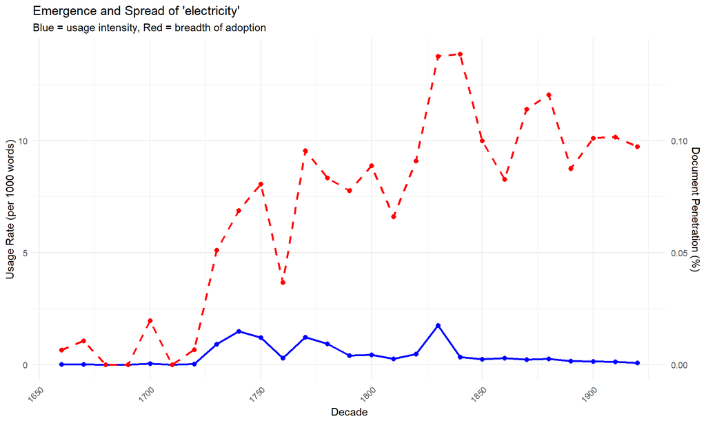

```r
# Visualise concept emergence
library(ggplot2)

plot_concept_emergence <- function(usage_data, term_name) {
  ggplot(usage_data, aes(x = time_period)) +
    geom_line(aes(y = usage_rate), color = "blue", size = 1) +
    geom_point(aes(y = usage_rate), color = "blue", size = 2) +
    geom_line(aes(y = document_penetration * 100), color = "red", size = 1, linetype = "dashed") +
    geom_point(aes(y = document_penetration * 100), color = "red", size = 2) +
    scale_y_continuous(
      name = "Usage Rate (per 1000 words)",
      sec.axis = sec_axis(~./100, name = "Document Penetration (%)")
    ) +
    labs(
      title = paste("Emergence and Spread of '", term_name, "'", sep = ""),
      subtitle = "Blue = usage intensity, Red = breadth of adoption",
      x = "Decade"
    ) +
    theme_minimal() +
    theme(axis.text.x = element_text(angle = 45, hjust = 1))
}

plot_concept_emergence(electricity_usage, "electricity")
```

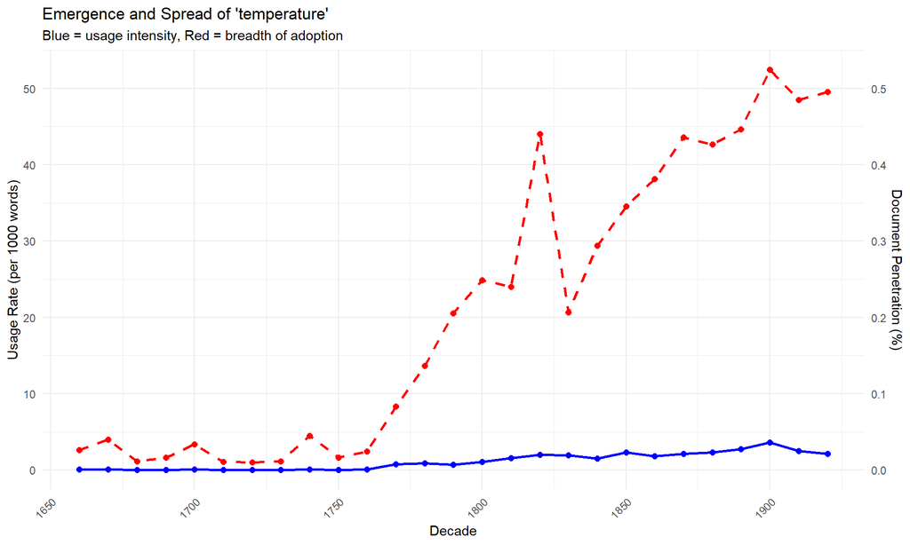

```r
plot_concept_emergence(temperature_usage, "temperature")
```

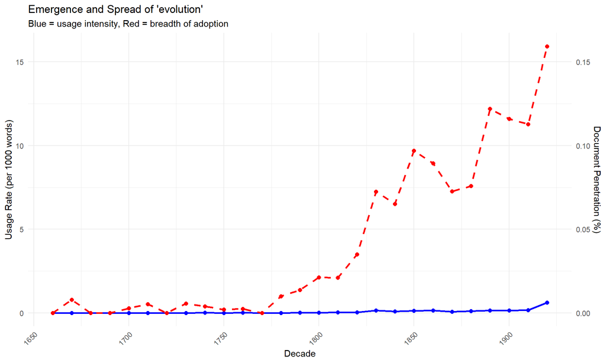

```r
plot_concept_emergence(evolution_usage, "evolution")
```

#### Interpreting Emergence Patterns

- Usage Rate: How intensively is a term used when it appears (occurrences per 1000 words)
- Document Penetration: How widely distributed is the term across different papers

Things one can look for:

- Sudden emergence: Terms that appear rarely then spike dramatically
- Gradual adoption: Concepts that slowly gain acceptance over decades
- Early vs. late adoption: Whether terms start in specialist contexts then spread
- Peak and decline: Whether certain concepts become less central over time

### 5.2 Authorial Expertise: Who Were the Key Figures for Specific Topics?

Instead of comparing predefined author groups, we can identify which authors were most central to specific scientific concepts or fields.

```r
# Find key authors for different scientific concepts
electricity_authors <- find_key_authors_for_term(rsc_dfm, "electricity", min_usage = 3)
temperature_authors <- find_key_authors_for_term(rsc_dfm, "temperature", min_usage = 5)
magnetic_authors <- find_key_authors_for_term(rsc_dfm, "magnetic", min_usage = 3)

cat("Top authors discussing 'electricity':\n")
```

```
## Top authors discussing 'electricity':
```

```r
print(head(electricity_authors, 10))
```

```
## # A tibble: 10 × 5
##    author total_term_usage total_words_written papers_using_term usage_intensity
##    <chr>             <dbl>               <int>             <int>           <dbl>
##  1 Micha…             1116              220171                62            5.07
##  2 Willi…              405               32338                16           12.5
##  3 W. Sn…              359               28863                 9           12.4
##  4 Tiber…              337               15319                 8           22.0
##  5 Humph…              329               72073                36            4.56
##  6 J. Fl…              311               36865                 3            8.44
##  7 Willi…              311               36865                 3            8.44
##  8 Willi…              202               13744                 6           14.7
##  9 J. T.…              176                4554                10           38.6
## 10 John …              171               10462                 3           16.3
```

```r
cat("\nTop authors discussing 'temperature':\n")
```

```
##
## Top authors discussing 'temperature':
```

```r
print(head(temperature_authors, 10))
```

```
## # A tibble: 10 × 5
##    author total_term_usage total_words_written papers_using_term usage_intensity
##    <chr>             <dbl>               <int>             <int>           <dbl>
##  1 Profe…             2030              230570                71            8.80
##  2 Georg…              878               93189                12            9.42
##  3 R. T.…              869               84237                26           10.3
##  4 J. No…              818              115361                39            7.09
##  5 Frank…              765               20397                 4           37.5
##  6 Arthu…              611               78474                28            7.79
##  7 Profe…              594               32505                 7           18.3
##  8 Sydne…              558               25949                12           21.5
##  9 E. H.…              527               40399                 9           13.0
## 10 J. A.…              527               32061                17           16.4
```

```r
cat("\nTop authors discussing 'magnetic' phenomena:\n")
```

```
##
## Top authors discussing 'magnetic' phenomena:
```

```r
print(head(magnetic_authors, 10))
```

```
## # A tibble: 10 × 5
##    author total_term_usage total_words_written papers_using_term usage_intensity
##    <chr>             <dbl>               <int>             <int>           <dbl>
##  1 "Mich…             1880              172472                45           10.9
##  2 "Edwa…             1034              140923                67            7.34
##  3 "A. W…              576               70306                 6            8.19
##  4 "Prof…              366               95056                25            3.85
##  5 "C. C…              344               51632                17            6.66
##  6 "T. E…              338               47574                 1            7.10
##  7 "J. A…              328               21049                12           15.6
##  8 "G. F…              269               17230                 4           15.6
##  9 "Will…              249                9569                 4           26.0
## 10 "Will…              240               32460                 9            7.39
```

```r
# Cross-reference with known historical figures
# (This would be where domain knowledge becomes valuable)
cat("\nUsage intensity shows how central a concept was to an author's work\n")
```

```
##
## Usage intensity shows how central a concept was to an author's work
```

```r
cat("(total mentions / total words written * 1000)\n")
```

```
## (total mentions / total words written * 1000)
```

### 5.3 Lexical Innovation: Tracking the Introduction of Technical Vocabulary

We can identify when new technical terms first appeared and trace their adoption patterns.

```r
# Find terminology that emerged in different centuries
innovations_1800s <- find_period_innovations(
  rsc_dfm,
  early_period = c(1600, 1650, 1700),
  late_period = c(1800, 1850),
  time_var = "century"
)

innovations_1900s <- find_period_innovations(
  rsc_dfm,
  early_period = c(1600, 1700, 1800),
  late_period = c(1900),
  time_var = "century"
)

cat("Top 20 lexical innovations appearing in 1800s:\n")
```

```
## Top 20 lexical innovations appearing in 1800s:
```

```r
print(head(innovations_1800s, 20))
```

```
##                      term total_usage docs_using usage_per_doc
## platinum         platinum        8351       1196      6.982441
## chloride         chloride        7458       1152      6.473958
## centims           centims        5763        445     12.950562
## millims           millims        5419        501     10.816367
## potassium       potassium        4771        867      5.502884
## grm                   grm        4748        242     19.619835
## galvanometer galvanometer        4370        559      7.817531
## ldquo               ldquo        4140        599      6.911519
## sodium             sodium        4065        847      4.799292
## iodide             iodide        4032        482      8.365145
## molecular       molecular        3996        868      4.603687
## chlorine         chlorine        3847        614      6.265472
## tissues           tissues        3013        678      4.443953
## hydrochloric hydrochloric        2883        674      4.277448
## electrodes     electrodes        2882        477      6.041929
## percentage     percentage        2672        562      4.754448
## photographs   photographs        2566        555      4.623423
## radial             radial        2496        386      6.466321
## iodine             iodine        2446        472      5.182203
## gaseous           gaseous        2435        711      3.424754
```

```r
cat("\nTop 20 lexical innovations appearing in 1900s:\n")
```

```
##
## Top 20 lexical innovations appearing in 1900s:
```

```r
print(head(innovations_1900s, 20))
```

```
##                        term total_usage docs_using usage_per_doc
## trypanosomes   trypanosomes        2105        136     15.477941
## trypanosome     trypanosome        1345        125     10.760000
## gambiense         gambiense         700         73      9.589041
## flagellates     flagellates         491         55      8.927273
## glossina           glossina         460         77      5.974026
## nyasaland         nyasaland         368         38      9.684211
## yeast-juice     yeast-juice         366         15     24.400000
## a-particles     a-particles         365         35     10.428571
## antiserum         antiserum         363         11     33.000000
## opsonic             opsonic         355         35     10.142857
## 7-rays               7-rays         350         35     10.000000
## brucei               brucei         344         56      6.142857
## 3-rays               3-rays         328         39      8.410256
## oxidase             oxidase         319          8     39.875000
## adrenalin         adrenalin         292         18     16.222222
## intumescences intumescences         289          6     48.166667
## mendelian         mendelian         276         54      5.111111
## opsonin             opsonin         264         24     11.000000
## wallibu             wallibu         262          6     43.666667
## trophoblast     trophoblast         259          7     37.000000
```

```r
# Focus on high-frequency innovations (likely important concepts)
cat("\nHigh-frequency innovations in 1800s (used > 20 times):\n")
```

```
##
## High-frequency innovations in 1800s (used > 20 times):
```

```r
innovations_1800s %>%
  filter(docs_using  > 20) %>%
  head(20)
```

```
##                      term total_usage docs_using usage_per_doc
## platinum         platinum        8351       1196      6.982441
## chloride         chloride        7458       1152      6.473958
## centims           centims        5763        445     12.950562
## millims           millims        5419        501     10.816367
## potassium       potassium        4771        867      5.502884
## grm                   grm        4748        242     19.619835
## galvanometer galvanometer        4370        559      7.817531
## ldquo               ldquo        4140        599      6.911519
## sodium             sodium        4065        847      4.799292
## iodide             iodide        4032        482      8.365145
## molecular       molecular        3996        868      4.603687
## chlorine         chlorine        3847        614      6.265472
## tissues           tissues        3013        678      4.443953
## hydrochloric hydrochloric        2883        674      4.277448
## electrodes     electrodes        2882        477      6.041929
## percentage     percentage        2672        562      4.754448
## photographs   photographs        2566        555      4.623423
## radial             radial        2496        386      6.466321
## iodine             iodine        2446        472      5.182203
## gaseous           gaseous        2435        711      3.424754
```

```r
cat("\nHigh-frequency innovations in 1900s (used > 20 times):\n")
```

```
##
## High-frequency innovations in 1900s (used > 20 times):
```

```r
innovations_1900s %>%
  filter(docs_using  > 20) %>%
  head(20)
```

```
##                            term total_usage docs_using usage_per_doc
## trypanosomes       trypanosomes        2105        136     15.477941
## trypanosome         trypanosome        1345        125     10.760000
## gambiense             gambiense         700         73      9.589041
## flagellates         flagellates         491         55      8.927273
## glossina               glossina         460         77      5.974026
## nyasaland             nyasaland         368         38      9.684211
## a-particles         a-particles         365         35     10.428571
## opsonic                 opsonic         355         35     10.142857
## 7-rays                   7-rays         350         35     10.000000
## brucei                   brucei         344         56      6.142857
## 3-rays                   3-rays         328         39      8.410256
## mendelian             mendelian         276         54      5.111111
## opsonin                 opsonin         264         24     11.000000
## kgrm                       kgrm         237         48      4.937500
## a-particle           a-particle         236         26      9.076923
## recessive             recessive         218         35      6.228571
## barkla                   barkla         217         48      4.520833
## jeans                     jeans         213         54      3.944444
## trypanosomiasis trypanosomiasis         205         50      4.100000
## rhodesiense         rhodesiense         201         40      5.025000
```

### 5.4 Diffusion Patterns: How Ideas Spread Through Scientific Networks

We can use text patterns to understand how concepts moved between different scientific communities or topics.

```r
# Track how key concepts spread across topics
electricity_by_topic <- track_concept_diffusion(rsc_dfm, "electricity", "primaryTopic")
temperature_by_topic <- track_concept_diffusion(rsc_dfm, "temperature", "primaryTopic")

cat("'Electricity' usage across primary topics:\n")
```

```
## 'Electricity' usage across primary topics:
```

```r
print(head(electricity_by_topic, 10))
```

```
## # A tibble: 10 × 7
##    group          total_usage docs_with_term total_docs total_words usage_rate
##    <chr>                <dbl>          <int>      <int>       <int>      <dbl>
##  1 Electricity           3736            410        820     1584236      2.36
##  2 Chemistry 1           2470            183        904     1300706      1.90
##  3 Fluid Dynamics         465             94        633     1161450      0.400
##  4 Biography              441            132        734     1248084      0.353
##  5 Meteorology            430             65        820     1339905      0.321
##  6 Thermodynamics         403            105        845     1712963      0.235
##  7 Biology 2              243             49       1305     1164580      0.209
##  8 Reporting              326             51       2217     1585130      0.206
##  9 Measurement            222             42        646     1122804      0.198
## 10 Nervous System         162             42        321      983424      0.165
## # ℹ 1 more variable: penetration_rate <dbl>
```

```r
cat("\n'Temperature' usage across primary topics:\n")
```

```
##
## 'Temperature' usage across primary topics:
```

```r
print(head(temperature_by_topic, 10))
```

```
## # A tibble: 10 × 7
##    group          total_usage docs_with_term total_docs total_words usage_rate
##    <chr>                <dbl>          <int>      <int>       <int>      <dbl>
##  1 Thermodynamics       17431            758        845     1712963      10.2
##  2 Tables                3337            183        452      765240       4.36
##  3 Measurement           4318            273        646     1122804       3.85
##  4 Biochemistry          2937            228        314      787542       3.73
##  5 Electricity           5186            427        820     1584236       3.27
##  6 Geography             2943            133        369      914728       3.22
##  7 Meteorology           4246            318        820     1339905       3.17
##  8 Atomic Physics        2557            306        560      938414       2.72
##  9 Chemistry 2           4158            653       1030     1541321       2.70
## 10 Physiology            1920            188        348      784185       2.45
## # ℹ 1 more variable: penetration_rate <dbl>
```

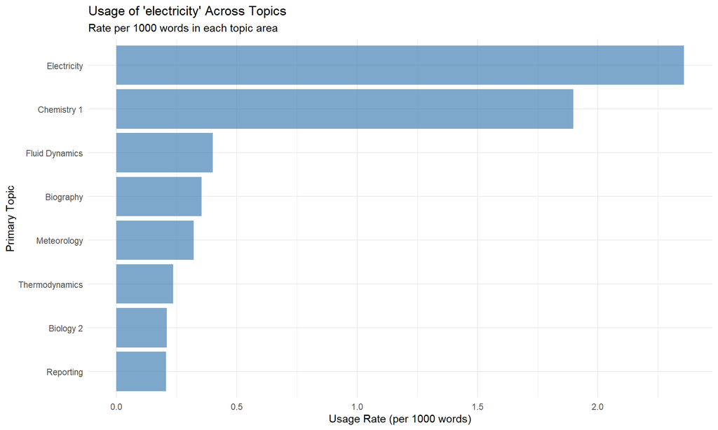

```r
# Visualise cross-topic diffusion
plot_topic_diffusion <- function(diffusion_data, term_name, top_n = 8) {
  diffusion_data %>%
    filter(total_usage > 0) %>%
    slice_head(n = top_n) %>%
    ggplot(aes(x = reorder(group, usage_rate), y = usage_rate)) +
    geom_col(fill = "steelblue", alpha = 0.7) +
    coord_flip() +
    labs(
      title = paste("Usage of '", term_name, "' Across Topics", sep = ""),
      subtitle = "Rate per 1000 words in each topic area",
      x = "Primary Topic",
      y = "Usage Rate (per 1000 words)"
    ) +
    theme_minimal()
}

plot_topic_diffusion(electricity_by_topic, "electricity")
```

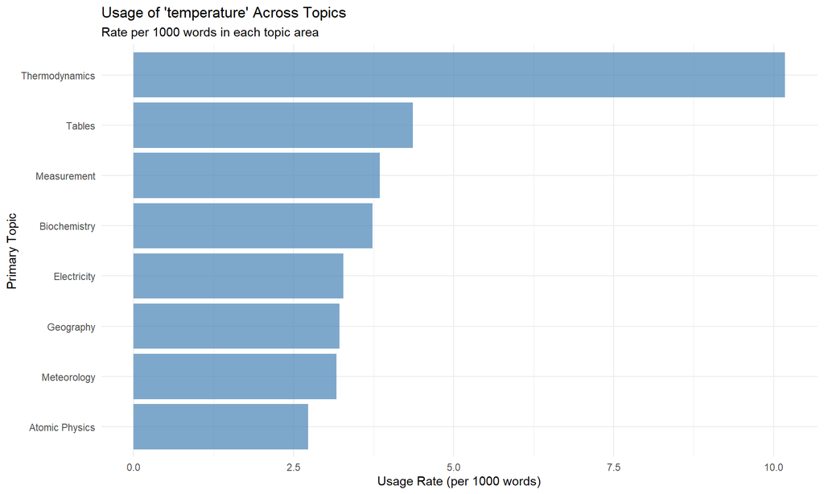

```r
plot_topic_diffusion(temperature_by_topic, "temperature")
```

### Text as Evidence for Broader Phenomena

This approach demonstrates how textual patterns can serve as evidence for historical, social, and intellectual processes. Rather than treating text as the object of study, we use it as a lens for understanding the metadata itself.

We can use this to generate empirically-grounded hypotheses about historical processes that can then be investigated using traditional historical methods—creating a productive dialogue between computational and humanistic approaches to understanding the past.

## 6. Network/Community Metadata: Intellectual Communities

**Research Questions:**

- How do different scholarly communities use language differently?
- What concepts are community-specific vs. shared across scientific networks?
- How do intellectual networks influence the spread of terminology?
- Which communities serve as bridges between different scientific domains?

**Methodological Strenght(s):** Network metadata reveals the social structure underlying scientific knowledge production. Different communities of scientists may develop distinct vocabularies, research methods, or ways of describing phenomena—even when studying related topics.

```r
# NB: Community zero represents isolates - needs to be dropped!
# Get the largest two communities for comparison
large_communities <- network_data %>%
  filter(all_time_communities != 0) %>%
  filter(node_type == "author", !is.na(all_time_communities)) %>%
  count(all_time_communities, sort = TRUE) %>%
  head(2) %>%
  pull(all_time_communities)

cat("Analysing communities:", paste(large_communities, collapse = ", "), "\n\n")
```

```
## Analysing communities: 97, 210
```

```r
# Subset DFM by YEARS and AUTHORS

# Create community-based subsets
dfm_comm1 <- subset_corpus(rsc_dfm, communities = large_communities[1])
dfm_comm2 <- subset_corpus(rsc_dfm, communities = large_communities[2])

# Overview of community subsets
cat("Community", large_communities[1], "Corpus:\n")
```

```
## Community 97 Corpus:
```

```r
cat("Documents:", ndoc(dfm_comm1), "\n")
```

```
## Documents: 448
```

```r
cat("Tokens:", sum(ntoken(dfm_comm1)), "\n")
```

```
## Tokens: 516416
```

```r
cat("\nCommunity", large_communities[2], "Corpus:\n")
```

```
##
## Community 210 Corpus:
```

```r
cat("Documents:", ndoc(dfm_comm2), "\n")
```

```
## Documents: 205
```

```r
cat("Tokens:", sum(ntoken(dfm_comm2)), "\n\n")
```

```
## Tokens: 553398
```

```r
# Compare vocabularies
cat("Top 15 Terms in Community", large_communities[1], ":\n")
```

```
## Top 15 Terms in Community 97 :
```

```r
topfeatures(dfm_comm1, 15) %>% print()
```

```
##         time          air         made          sun        water        found
##         3230         2612         2596         2037         2036         1918
## observations        point     distance        equal     observed        small
##         1718         1666         1548         1477         1410         1349
##         less       little         line
##         1261         1223         1188
```

```r
cat("\nTop 15 Terms in Community", large_communities[2], ":\n")
```

```
##
## Top 15 Terms in Community 210 :
```

```r
topfeatures(dfm_comm2, 15) %>% print()
```

```
##       cells       found        side        case     surface development
##        4116        1829        1443        1413        1408        1387
##        form        time       blood    solution     section       stage
##        1371        1353        1325        1247        1233        1219
##       organ     present        body
##        1213        1209        1178
```

```r
# Find community-distinctive terms using keyness
combined_dfm <- rbind(dfm_comm1, dfm_comm2)
docvars(combined_dfm, "subset") <- c(rep("subset1", ndoc(dfm_comm1)),
                                        rep("subset2", ndoc(dfm_comm2)))

# Calculate keyness
keyness_results <- textstat_keyness(combined_dfm,
                                  target = docvars(combined_dfm, "subset") == "subset1")

cat("\nTerms most distinctive of Community", large_communities[1], ":\n")
```

```
##
## Terms most distinctive of Community 97 :
```

```r
keyness_results %>%
  filter(chi2 > 0) %>%
  arrange(desc(chi2)) %>%
  head(10) %>%
  print()
```

```
##     feature      chi2 p n_target n_reference
## 1       air 2182.7334 0     2612         226
## 2       sun 2105.4182 0     2037          27
## 3  distance 1052.4417 0     1548         240
## 4      moon 1024.9594 0      967           4
## 5     earth 1015.4479 0      975          10
## 6   gravity  939.7354 0      964          32
## 7     equal  935.6592 0     1477         263
## 8      time  908.9613 0     3230        1353
## 9     angle  877.1961 0     1100         112
## 10   motion  843.6930 0     1070         113
```

```r
cat("\nTerms most distinctive of Community", large_communities[2], ":\n")
```

```
##
## Terms most distinctive of Community 210 :
```

```r
keyness_results %>%
  filter(chi2 < 0) %>%
  arrange(chi2) %>%
  head(10) %>%
  print()
```

```
##        feature       chi2 p n_target n_reference
## 1        cells -3660.2247 0       68        4116
## 2  development -1063.6306 0       86        1387
## 3        stage -1056.4068 0       29        1219
## 4        nerve -1036.5810 0       20        1171
## 5        organ -1023.6081 0       39        1213
## 6        layer  -927.9788 0        4        1006
## 7    posterior  -922.9706 0        8        1013
## 8         cell  -914.5759 0       28        1064
## 9     anterior  -871.9917 0        3         943
## 10      dorsal  -862.9971 0        0         924
```

### Interpreting Community Results

Keyness reveals:

- Community-specific vocabularies: Terms that strongly characterise each intellectual network
- Disciplinary boundaries: How different scientific domains maintain distinct languages
- Methodological differences: Communities may prefer different research approaches or instruments
- Theoretical orientations: Distinct ways of conceptualising similar phenomena

These differences reflect how scientific communities develop their own research traditions, methodological preferences, and ways of understanding the natural world.

### Community Makeup

We are also able to look at who the people are that make up these communities, what they wrote, and what they wrote about.

```r
# NB: Community zero represents isolates - needs to be dropped!
# Get the largest communities for meaningful comparison
slice_communities <- network_data %>%
  filter(slice_1725_1774 != 0) %>%
  filter(node_type == "author", !is.na(slice_1725_1774)) %>%
  count(slice_1725_1774, sort = TRUE) %>%
  #head(5) %>%
  pull(slice_1725_1774)

# Create community-based subsets (chose 6 and 8 for illustrative purposes)
dfm_comm1 <- subset_corpus(rsc_dfm, communities = slice_communities[6], time_slice = "slice_1725_1774")
dfm_comm2 <- subset_corpus(rsc_dfm, communities = slice_communities[8], time_slice = "slice_1725_1774")

# Overview of community subsets
cat("Community", slice_communities[6], "Corpus:\n")
```

```
## Community 3 Corpus:
```

```r
cat("Documents:", ndoc(dfm_comm1), "\n")
```

```
## Documents: 71
```

```r
cat("Tokens:", sum(ntoken(dfm_comm1)), "\n")
```

```
## Tokens: 63934
```

```r
cat("\nCommunity", slice_communities[8], "Corpus:\n")
```

```
##
## Community 30 Corpus:
```

```r
cat("Documents:", ndoc(dfm_comm2), "\n")
```

```
## Documents: 100
```

```r
cat("Tokens:", sum(ntoken(dfm_comm2)), "\n\n")
```

```
## Tokens: 127495
```

```r
# Compare vocabularies
cat("Top 15 Terms in Community", slice_communities[6], ":\n")
```

[output not shown]

```r
topfeatures(dfm_comm1, 25) %>% print()
```

```
##         time         limb          sun         made        found        clock
##          641          456          407          374          289          285
## observations        equal        point       motion         line     observed
##          277          277          270          216          209          204
##          air     distance        earth        place         moon         near
##          200          191          186          185          182          172
##          end        parts        shall        right      greater   difference
##          170          168          166          163          159          159
##          day
##          153
```

```r
cat("\nTop 15 Terms in Community", slice_communities[8], ":\n")
```

[output not shown]

```r
topfeatures(dfm_comm2, 25) %>% print()
```

```
##      animal       parts     animals        made        time       water
##         696         514         511         471         452         441
##       small       found   different        heat      little       every
##         429         413         367         338         334         321
##        body     species experiments      called       whole      common
##         298         288         282         281         278         275
##      motion     muscles        side         see     surface        kind
##         268         263         257         249         247         246
##     several
##         244
```

```r
# The titles of five random documents
cat("The titles of five random documents\n")
```

```
## The titles of five random documents
```

```r
docvars(dfm_comm1)$title[c(sample(c(1:ndoc(dfm_comm1)), 5))]
```

```
## [1] "An Account of the Evaporation of Water, as It Was Experimented in Gresham Colledge in the Year 1693. With Some Observations Thereon. By Edm. Halley"
## [2] "A Rule for Finding the Meridional Parts to Any Spheroid, with the Same Exactness as in a Sphere, by Colin Mac Laurin, F. R. S. Communicated by Andrew Mitchel, Esq; F. R. S."
## [3] "An Observation on an Occultation of Cor Leonis by the Moon, on Thursday, March 12. 1747, in Surrey-Street in the Strand, London, with a Reflecting Telescope, Made by Mr. Short, F. R. S. Which Magnified about 100 Times; Communicated to the Royal Society by J. Bevis, M. D."
## [4] "The Art of Living under Water: Or, a Discourse concerning the Means of Furnishing Air at the Bottom of the Sea, in Any Ordinary Depths. By Edm. Halley, LL. D. Secretary to the Royal Society"
## [5] "Extracts of Two Letters from the Late Roger Gale, Esquire, F. R. S. to Mr. Peter Collinson, F. R. S. concerning the Vegetation of Melon Seeds 33 Years Old; And of a Fossil Skeleton of a Man"
```

```r
docvars(dfm_comm2)$title[c(sample(c(1:ndoc(dfm_comm1)), 5))]
```

```
## [1] "A Letter from John Ellis, Esq; F. R. S. to the President, on the Coluber Cerastes, or Horned Viper of Egypt"
## [2] "An Account of the White Negro Shewn before the Royal Society: In a Letter to the Right Honourable the Earl of Morton, President of the Royal Society, from James Parsons, M. D. F. R. S."
## [3] "Letters of the Abb\\#xE9; Mazeas, F. R. S. to the Rev. Stephen Hales, D. D, F. R. S. concerning the Success of the Late Experiments in France. Translated from the French by James Parsons, M. D. F. R. S."
## [4] "An Answer to the Preceding Remarks. By Mr. John Ellis, F. R. S."
## [5] "An Account of the Actinia Sociata, or Clustered Animal-Flower, Lately Found on the Sea-Coasts of the New-Ceded Islands: In a Letter from John Ellis, Esquire, F. R. S. to the Right Honourable the Earl of Hillsborough, F. R. S."
```

```r
# The (computationally assigned) topics for documents in the communities
cat("The (computationally assigned) topics for documents in the communities\n")
```

```
## The (computationally assigned) topics for documents in the communities
```

```r
sort(table(docvars(dfm_comm1)$primaryTopic), decreasing = TRUE)
```

```
##
##      Astronomy      Reporting    Chemistry 1    Measurement    Meteorology
##             41             10              5              5              4
##       Formulae   Biochemistry      Biology 2 Fluid Dynamics
##              3              1              1              1
```

```r
sort(table(docvars(dfm_comm2)$primaryTopic), decreasing = TRUE)
```

```
##
##    Biology 2    Reporting     Botany 2  Chemistry 1    Biology 1 Paleontology
##           42           26           13           12            3            3
##    Astronomy
##            1
```

```r
# The top 5 authors in each community
cat("The top 5 authors in each community\n")
```

```
## The top 5 authors in each community
```

```r
sort(table(unlist(docvars(dfm_comm1)$authors_list)), decreasing = TRUE)[1:5]
```

```
##
##   Edm. Halley      J. Bevis George Graham   John Hadley Charles Mason
##            15            13             9             9             8
```

```r
sort(table(unlist(docvars(dfm_comm2)$authors_list)), decreasing = TRUE)[1:5]
```

```
##
## James Parsons    John Ellis   John Hunter  Peter Woulfe Philip Miller
##            37            28            25             6             6
```

And let’s plot these networks:

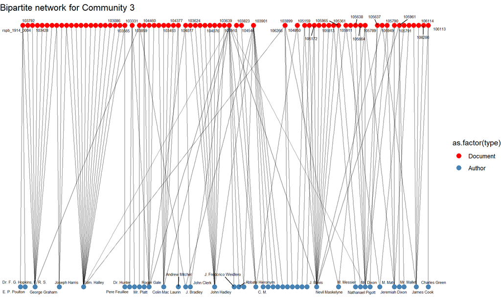

```r
edges_comm1 <- make_bipartite_edges(dfm_comm1)
edges_comm2 <- make_bipartite_edges(dfm_comm2)

plot_bipartite(edges_comm1, slice_communities[6])
```

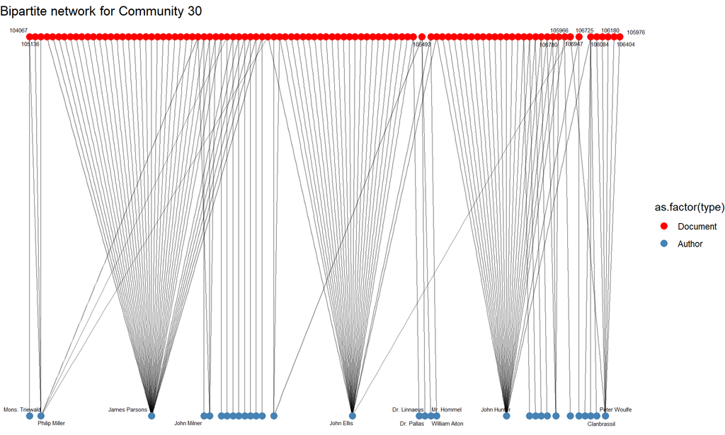

```r
plot_bipartite(edges_comm2, slice_communities[8])
```

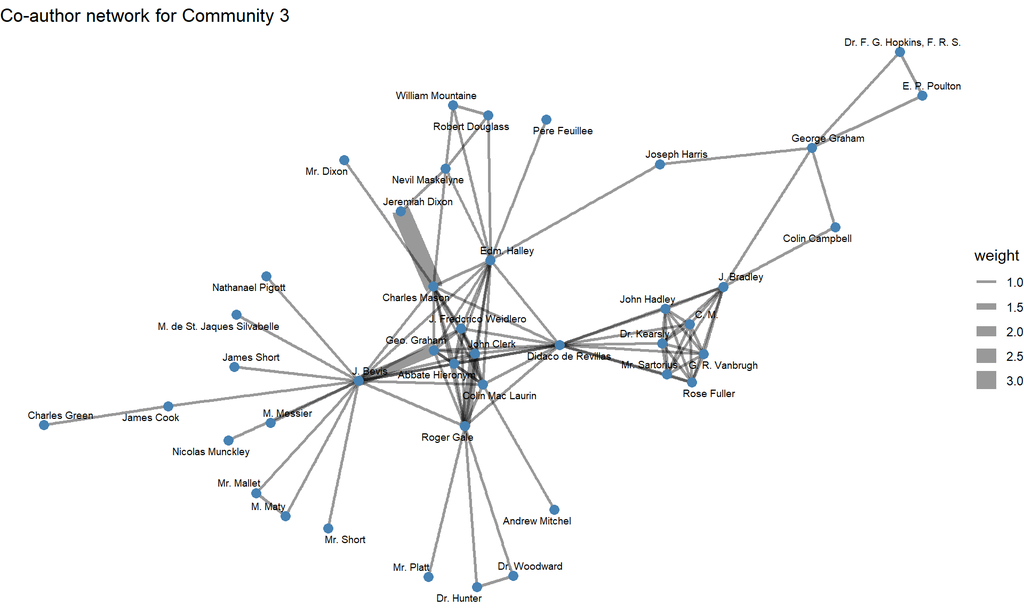

```r
plot_coauthors(edges_comm1, slice_communities[6])
```

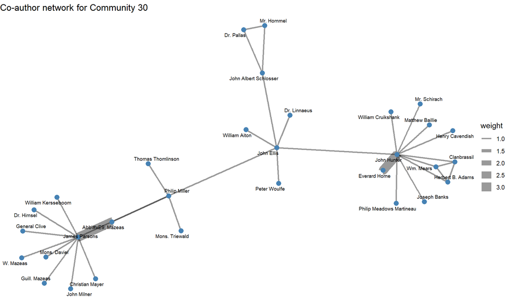

```r
plot_coauthors(edges_comm2, slice_communities[8])
```

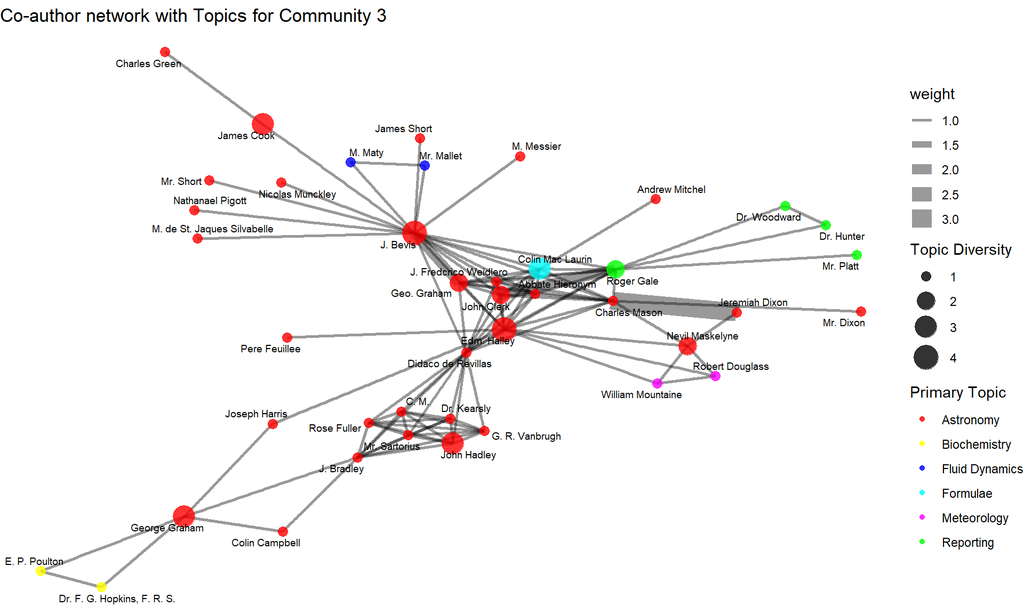

```r
plot_coauthors_with_topics(dfm_comm1, edges_comm1, slice_communities[6])
```

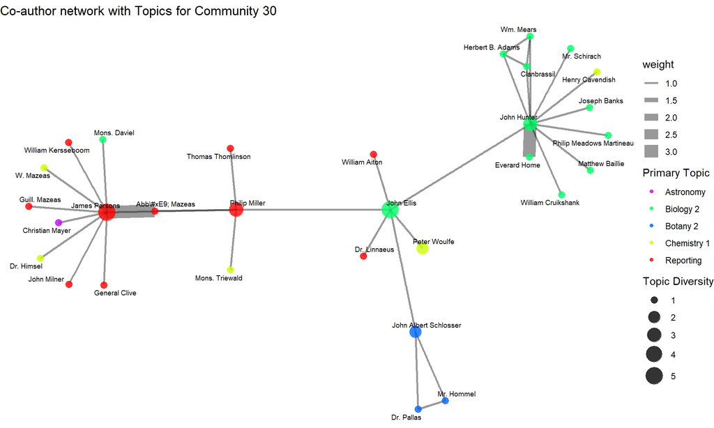

```r
plot_coauthors_with_topics(dfm_comm2, edges_comm2, slice_communities[8])
```

# Summary

What we’ve tried to demonstrate here is that **metadata can fundamentally determines what research questions are possible to ask and answer when using text.** Each type of metadata creates new analytical possibilities (or lenses).

## Implications for Text Analysis

- **1. Research Design:** Always begin by cataloging available metadata and considering what questions each dimension enables
- **2. Data Collection:** Invest heavily in metadata acquisition as it’s potentially more valuable than additional raw text
- **3. Analytical Strategy:** Design analysis plans that start with basic questions and allow for the addition of dimensions progressively
- **4. Interpretation:** Context from metadata is essential for moving from pattern detection to meaningful explanation
- **5. Reproducibility:** Document metadata schemas and subsetting criteria as carefully as analytical procedures

## Practical Implications and strategies for your research

### Two general approaches

**Exploratory Data Analysis (EDA)**

- Start simple: basic frequency analysis
- Build Complexity by layering different metadata dimensions
- Ask bigger questions (maybe… research questions) as you develop an understanding of your data and the substantive context

**Start with your research question(s)**

- Guided by domain expertise
- What do you want to know?
- What metadata would enable that analysis?
- Work backwards from question to data requirements

### Concluding notes

**Metadata is not optional**

- Determines analytical possibilities
- Invest time in understanding (and enriching) metadata

**Layer your analysis**

- Begin with simple, single-dimensional analyses
- Gradually combine metadata types for richer insights
- Each combination unlocks new research possibilities

**Document structure can be metadata**

Even without explicit categories, text structure provides context, e.g.:

- Network analysis from co-occurrence patterns
- Temporal patterns from publication sequences
- Topic modeling to categorise document
- Text itself (tokens) can be used to understand metadata

# Exercise Template

```r
# TEMPLATE FOR EXERCISE ANALYSIS
# Modify these parameters to explore different questions:

# Step 1: Choose your comparison:
my_decade1 <- 1850  # or any decade
my_decade2 <- 1900  # or any decade
my_topic <- "Geology"  # or any available topic
my_community <- 1  # or any available community

# Step 2: Create your subsets:
my_dfm1 <- subset_corpus(rsc_dfm, decade = my_decade1, topics = my_topic)
my_dfm2 <- subset_corpus(rsc_dfm, decade = my_decade2, topics = my_topic)

# Step 3: Analyse and compare (top features, keyness)

# Reflection questions for yourself:
# 1. What research question does your comparison address?
# 2. How did the metadata enable this specific question?
# 3. What would be impossible to answer without this metadata?
# 4. What additional metadata would enable even more interesting questions?
```